# RPlots_assing

```r
## Reading the soil temperature file

datacsv <- read.csv("Site_A_Soil_Temp.csv",header=FALSE, stringsAsFactors=FALSE)
datacsv = datacsv[, !(colnames(datacsv) %in% c("V4","V5","V6","V7","V8"))]
datacsv = datacsv[(!duplicated(datacsv$V2)  & !grepl("Plot",datacsv$V1) & !grepl("#",datacsv$V1)),] # Removing the duplicate values and some bad values
colnames(datacsv)
```

```
## [1] "V1" "V2" "V3"
```

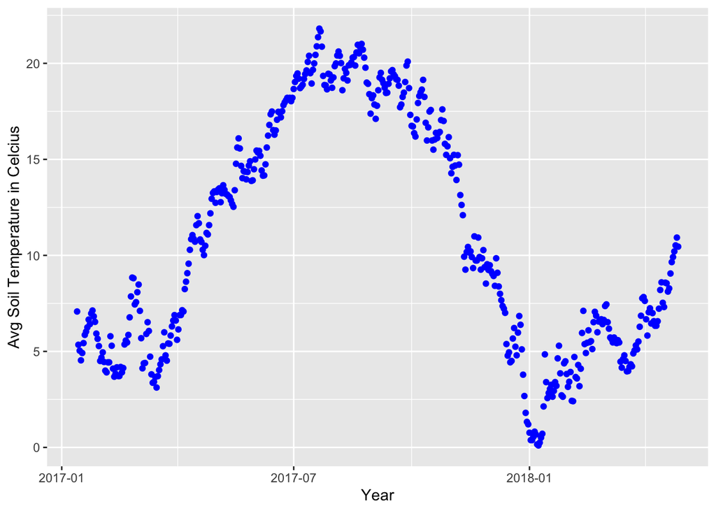

```r
names(datacsv)[names(datacsv) == "V1"] <- "Seq"
names(datacsv)[names(datacsv) == "V2"] <- "Date&Time"
names(datacsv)[names(datacsv) == "V3"] <- "Temperature" # Renaming the column names to sensible one

datacsv$`Date&Time`= as.Date(datacsv$`Date&Time`, format = "%m/%d/%y") # converting Charcolumn to Date column

datacsv$Temperature = as.numeric(datacsv$Temperature) # converting to numeric column

cdata <- summaryBy(Temperature ~ datacsv$`Date&Time`, data=datacsv, FUN=c(min,max,mean),is.na=TRUE) # Calulate Min, Max, MEan Temperature


Data_intensity <- read.csv("/Users/hitesh/Desktop/datasheet_1569537798494/status_intensity_observation_data.csv", header=TRUE, stringsAsFactors = FALSE)

dint <- data.frame(Data_intensity$Observation_Date,Data_intensity$Site_Name,Data_intensity$Species,Data_intensity$Phenophase_Name,Data_intensity$Intensity_Value) # Taking Subset for required columns from Intensity Data

dint$Data_intensity.Observation_Date <- as.Date(dint$Data_intensity.Observation_Date) # converting to Date column

dintA <- subset(dint,dint$Data_intensity.Site_Name=="Site A" & dint$Data_intensity.Phenophase_Name=="Breaking leaf buds")

SiteASoil <- inner_join(dintA,cdata,by=c("Data_intensity.Observation_Date"="Date&Time") , is.na=TRUE) # using inner join to merge two dataset with common column "Observation date"


# Creating plots for the mean soil temp on a tearly basis
ggplot()+
  geom_point(data=cdata,aes(x=cdata$`Date&Time`,y=cdata$Temperature.mean),color="Blue")+
  ylab("Avg Soil Temperature in Celcius")+
  xlab("Year")
```

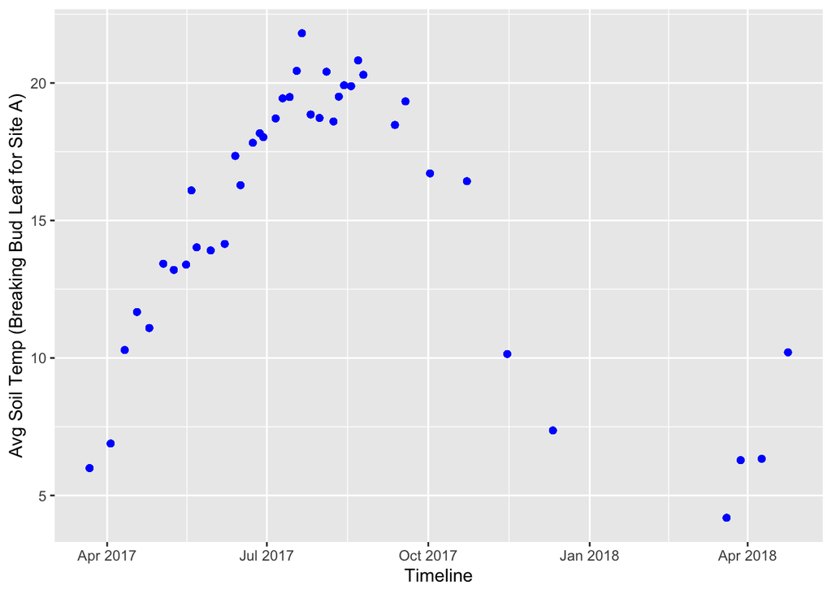

```r
ggplot()+
  geom_point(data=SiteASoil,aes(x=SiteASoil$Data_intensity.Observation_Date,y=SiteASoil$Temperature.mean),color="Blue")+
  xlab("Timeline")+ ylab("Avg Soil Temp (Breaking Bud Leaf for Site A)")
```

For the above Rplot, we have taken two variables Average Soil Temperature and Date&Time. Avg Temperature is on Y axis as **Avg Temperature in Celcius** and Date$time is on X-axis as **Year**. As we can explian the variablity of Temperature across the years. Prediction of Temperature is useful to study about phenophases of plant species.

Above Rplot suggested that Temperature in January is nearly about 5 Celcius and gradually increases from January 2017 to July - August 2017 and then Temperature again declining.

[figure not shown]

```r
# PLOTTING TEMPERATURE DATA FILES

#files <- list.files(path="temperature", pattern="*.csv", full.names=TRUE, recursive=FALSE)
#files
#for(file in files) {
#  file <- ldply(file,read_csv)
#  ggplot()+geom_point(data=file,aes(x=file$`Date&Time`,y=file$Temperature.mean),color="Blue")+ylab("Avg Air Temperature in Celcius")+xlab("Date")
#}

analyze <- function(filename) {
  # Plots the average, min, and max inflammation over time.
  # Input is character string of a csv file.
  dataset <- read_csv(file = filename)
  ggplot()+geom_point(data=dataset,aes(x=dataset$`Date&Time`,y=dataset$Temperature.mean),color="Blue")+ylab("Avg Air Temperature in Celcius")+xlab("Date")
}

analyze("siteA.csv")
```

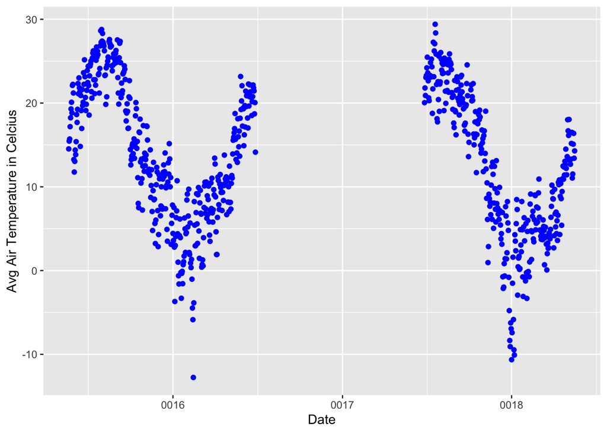

```r
analyze("SiteB.csv")
```

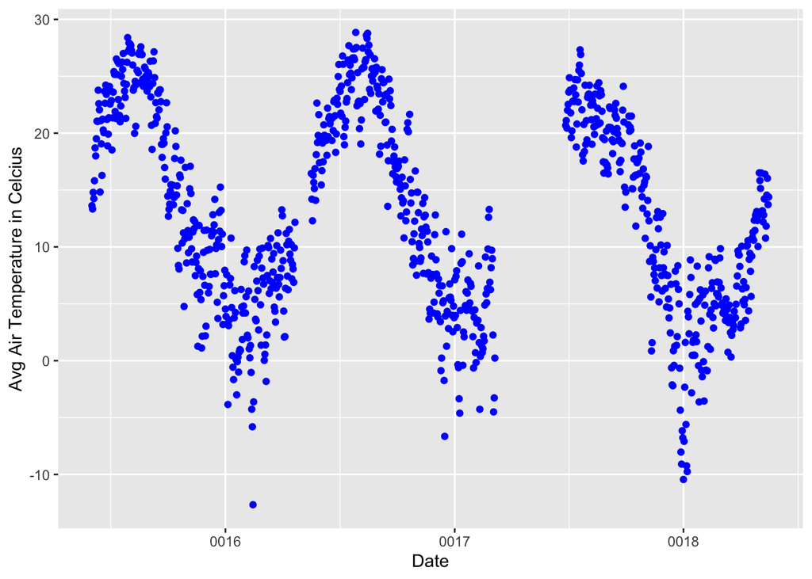

```r
analyze("siteC.csv")
```

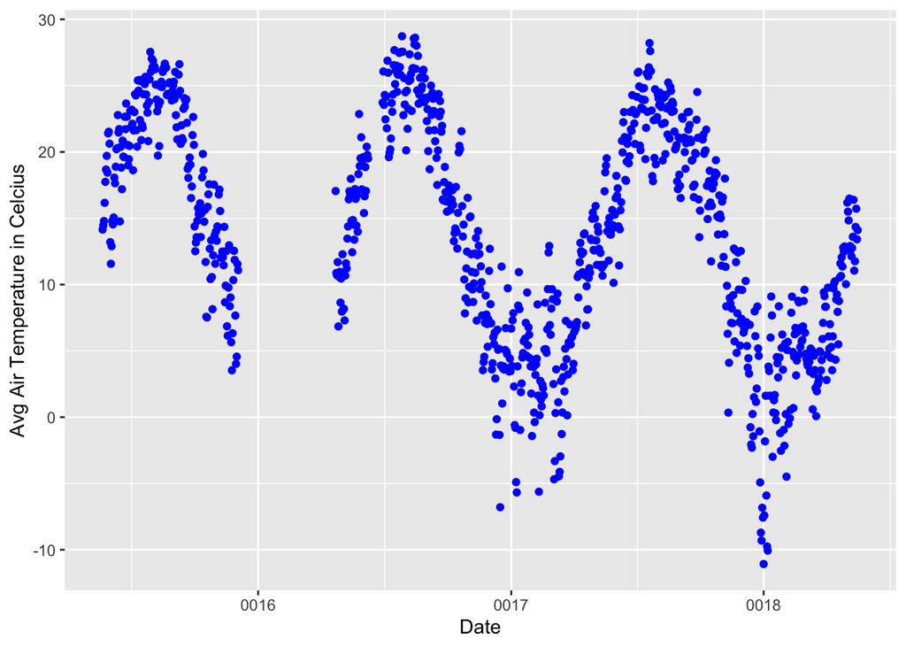

```r
analyze("SiteD.csv")
```

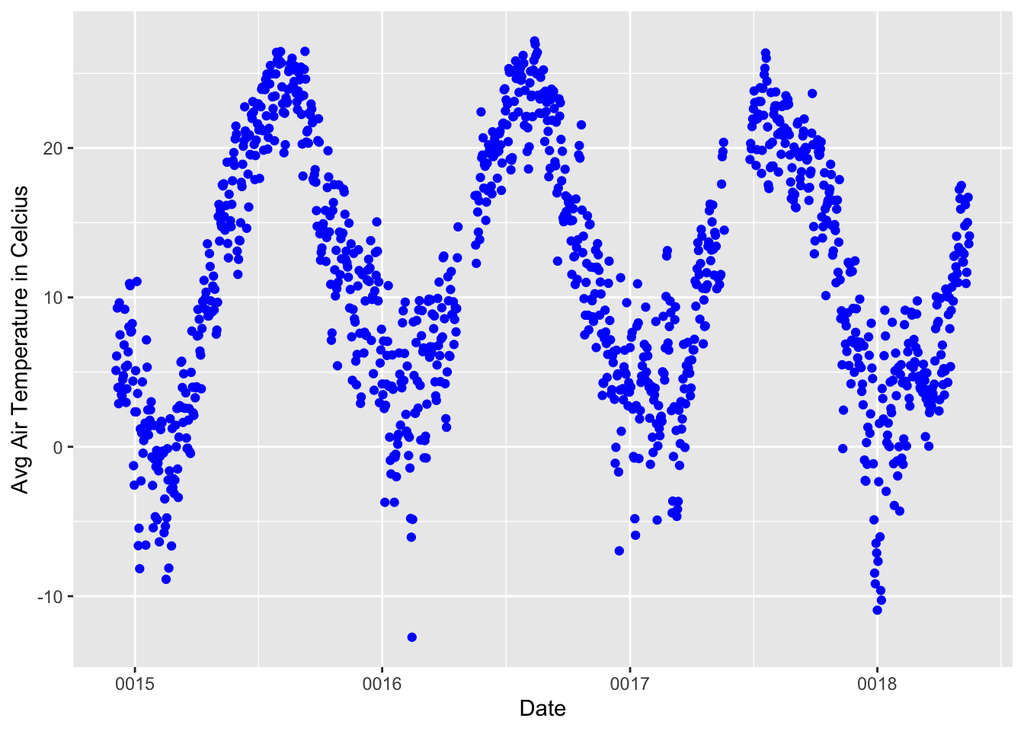

```r
analyze("siteE.csv")
```

[figure not shown]

```r
analyze("SiteF.csv")
```

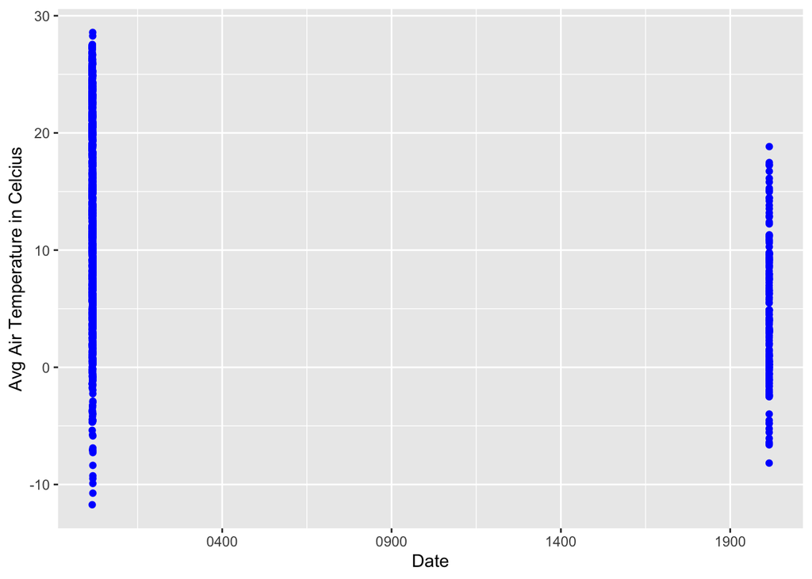

```r
analyze("siteG.csv")
```

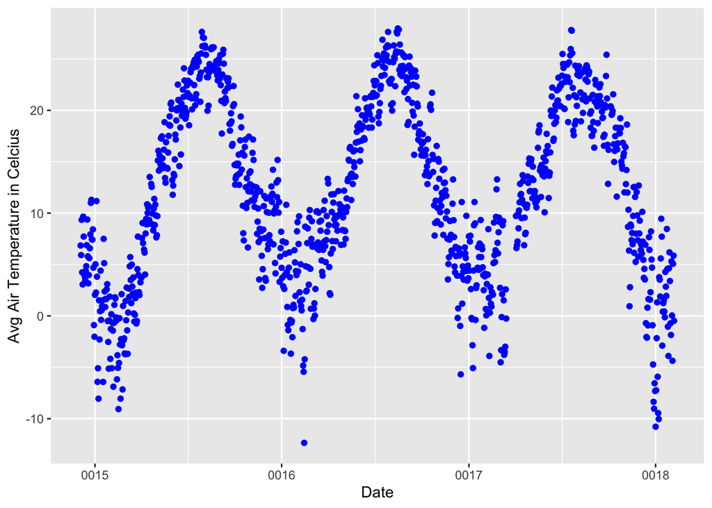

```r
analyze("SiteH.csv")
```

Importance of this Plot: Dr Sarah Bois wanted o analyse the effects of Temperature on Phenophase **Breaking Bud Leaf**, so this Rplot will help them in their reaserch.

*CONTRIBUTORSHIP STATEMENT* : Dhwani and Menglin contributed to all R plots and Scripts.

*PROOFREADER STATEMENT*: Ranga Tanishk Reddy did review and proofread the whole work to be submitted.